# Medellivslängd eller förtida död?

# Inledning

Denna studie syftar till att jämföra medellivslängd med förtida död då de appliceras på relativt små geografiska områden. Följande frågeställningarutreds:

1. Hur har medellivslängd respektive förtida dödsfall utvecklats över tid?
2. Hur stor är korrelationen mellan medellivslängd och förtida död?
3. Vilken geografisk nivå är lämplig som aggregeringsnivå?
4. Hur påverkas precisionen av att poola data över flera år, som rullande 3/5-årsmedelvärden?

# Data

## Antal döda

Data över antalet döda män och kvinnor 1990-2018 uppdelat på 1-årsintervall, bo-kommun och VG, hämtas från SCBs publika databas via myndighetens API och sparas ned till två filer, `deaths.RData` och `pop.RData`:

Filerna sparas separat på grund av att de tar relativt lång tid att ladda bned dem. Därefter slås de båda filerna ihop till en arbetsfil, `df_mort` :

```r
library(tidyverse)
library(demography)
library(roll)
library(huxtable)

df_mort <- read.csv2("data/1_premdeaths/df_mort.csv", encoding = "UTF-8")
```

# Metod

1. åldersspecifik dödsrisk
2. populationens storlek
3. populationens åldersfördelning (åldersspecifik populationsstorlek)

ad 1. Antalet döda betraktas som en Poisson-fördelad variabel med väntevärdet $\lambda$

$$m_i = \frac{x_i}{n_i} \tag{1}$$

$$x_i \sim Poisson(\lambda = m_{vg}*n_i) \tag{2}$$

där $x_i$ är antalet dödsfall i åldersintervallet *i*, $n_i$ är antalet i befolkningen i samma åldersintervall. $m_{vg}$ är dödsrisken för populationen i hela Västra Götaland i åldersintervallet. Vi antar alltså att den underliggande dödsrisken i ett visst åldersintervall i en viss kommun är densamma som för länet.

Indikatorn förtida död beräknas genom att dividera antalet dödsfall som inträffar innan 65 års ålder dividerat med folkmängden (31 dec resp år) under 65 års ålder.

$$m = \frac{\sum_{i=0}^{64} x_i}{\sum_{i=0}^{64} n_i} \tag{3}$$

```r
### life_exp.R

# libs --------------------------------------------------------------------

library(tidyverse)
library(demography)


# data --------------------------------------------------------------------

df_le <- df_mort %>%
  filter(!is.na(ålder))

df_le_m <- df_mort %>%
  filter(region == "14 Västra Götalands län" & kön == "män" & !is.na(ålder)) %>%
  mutate(mort = cases/antal) %>%
  arrange(year, ålder)

df_le_1421 <- df_mort %>%
  filter(region == "1421 Orust" & kön == "män" & !is.na(ålder)) %>%
  mutate(mort = cases/antal) %>%
  arrange(year, ålder)

df_p_m <- df_mort %>%
  filter(region == "14 Västra Götalands län" & kön == "män" & !is.na(ålder)) %>%
  arrange(year, ålder)

df_le_f <- df_mort %>%
  filter(region == "14 Västra Götalands län" & kön == "kvinnor" & !is.na(ålder)) %>%
  mutate(mort = cases/antal) %>%
  arrange(year, ålder)

df_p_f <- df_mort %>%
  filter(region == "14 Västra Götalands län" & kön == "kvinnor" & !is.na(ålder)) %>%
  arrange(year, ålder)



# medellivslängd ----------------------------------------------------------

## män
mx_mort_m <- matrix(df_le_m$mort, ncol = 29, byrow = FALSE)
mx_pop_m <- matrix(df_le_m$antal, ncol = 29, byrow = FALSE)

dg_mort_m <- demogdata(data = mx_mort_m, pop = mx_pop_m, ages = 0:90, years = 1990:2018,
                     type = "mortality", label = "VG", name = "male")

le_male <- e0(dg_mort_m)

mx_mort_f <- matrix(df_le_f$mort, ncol = 29, byrow = FALSE)
mx_pop_f <- matrix(df_le_f$antal, ncol = 29, byrow = FALSE)

dg_mort_f <- demogdata(data = mx_mort_f, pop = mx_pop_f, ages = 0:90, years = 1990:2018,
                       type = "mortality", label = "VG", name = "female")

le_fem <- e0(dg_mort_f)


# förtida död -------------------------------------------------------------

df_prem65 <- df_mort %>%
  filter(region == "14 Västra Götalands län" & ålder < 65) %>%
  group_by(kön, year) %>%
  summarise(cases = sum(cases),
            antal = sum(antal)) %>%
  mutate(mort = cases/antal)

mort_m65 <- df_prem65$mort[df_prem65$kön == "män"]

mort_f65 <- df_prem65$mort[df_prem65$kön == "kvinnor"]

df_comp <- data.frame(mort_m65, le_m = as.numeric(le_male), mort_f65, le_f = as.numeric(le_fem))
```

Korrelationen (Spearman´s) mellan medellivslängd och förtida död beräknas för perioden 1990 till 2018.

**Den tredje frågeställningen** handlar om vilken aggregeringsnivå som kan vara rimlig beträffande precisionen. Tentativt uppfattas att en precision beträffande medellivslängd på $\pm$ 0.2 levnadsår kan vara rimlig medan en rimlig precision beträffande förtida dödsfall kan vara $\pm$ 20 dödsfall per 100 000. Här använder jag data för 1990 och beräknar dels medellivslängden per kommun, dels dödlihet i förtid per kommun (1990 för att antalet dödsfall var som högst under den studerade perioden) på samma sätt som ovan.  
Jag använde Monte Carlo-teknik för att simulera en fördelning av antalet döda per 1-årsåldersintervall och per kommun, med den åldersspecifika dödligheten i Västra Götaland tillsammans med den ålderspecifika befolkningsstorleekn i respektive kommun (se ekvation (2) ovan). Den åldersspecifika dödligheten och befolknigsstorleken användes för att konstruera de två matriser som behövs för att upprätta livslängdstabeller i `demography` ur vilka medellivslängden sedan lätt kan extraheras (argumenten `data` och `pop`).

I ett andra steg beräknades standardfelet för skattningarna av medellivslängd respektive förtida dödsfall för olika (hypotetiska) populationsstorlekar (från 1000 till 200 000). På så sätt kan en rimlig precision “titreras” ut. Här använde jag också en Monte Carlo-simulering för att generera en fördelning av respektive indikator. Från dessa beräknades medelvärde och standardavvikelse för varje nivå av populationsstorleken.

För att besvara **den fjärde frågeställningen** undersöker jag hur prcisionen förändras då data poolas dels över tid, dels geografiskt. Beräkningarna enligt ovan görs med 1) data poolade över 3- respektive 5-årsintervall, och 2) data poolade över lokala arbetsmarknader samt över kommunalförbundsområden.

För beräkningarna användes R ver 3.5.0, för beräkningen av medellivslängd `demography`-paketet.

# Resultat

## Medellivslängdens utveckling 1990 - 2018

Medellivslängden har ökat för både kvinnor ocjh män. För männen från 75.6 i början av 1990-talet till 81 år 2018. Motsvarande ökning för kvinnor är 80.9 år 1990, 84.3 år 2018 (se figur nedan).

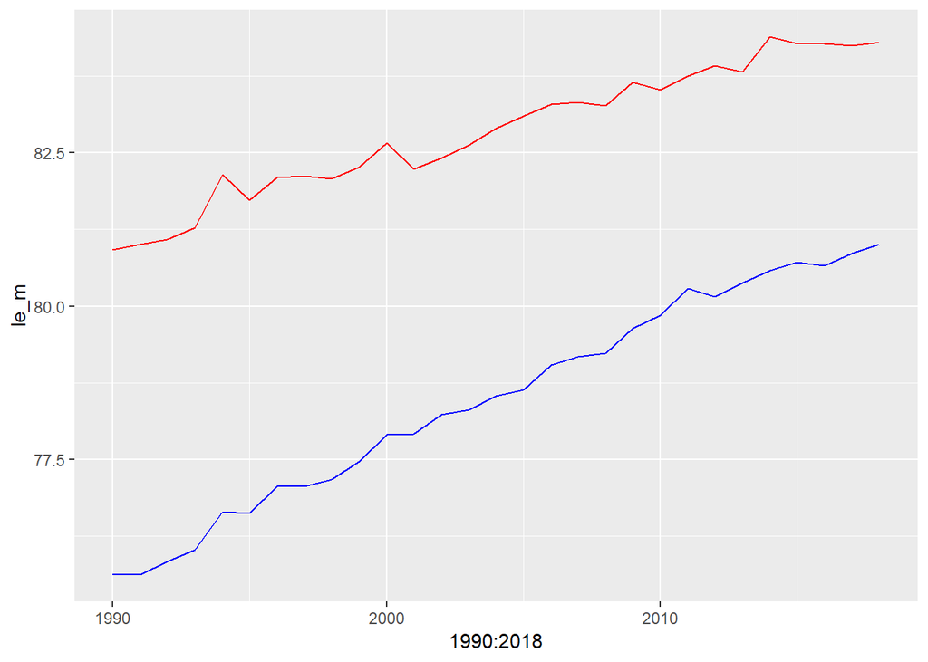

Medellivslängd för kvinnor och män 1990 - 2018 i Västra Götaland

```r
# df_comp <- data.frame(mort_m65, le_m = as.numeric(le_male), mort_f65, le_f = as.numeric(le_fem))

ggplot(df_comp) +
  geom_line(aes(x = 1990:2018, y = le_m), col = 4)+
  geom_line(aes(x = 1990:2018, y = le_f), col = 2)
```

```r
#legend ska läggas till
```

## Utvecklingen av förtida dödsfall 1990 - 2018

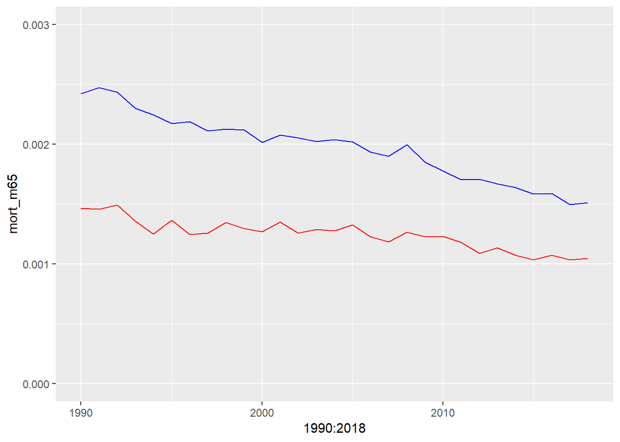

```r
ggplot(df_comp) +
  geom_line(aes(x = 1990:2018, y = mort_m65), col = 4)+
  geom_line(aes(x = 1990:2018, y = mort_f65), col = 2)+
  ylim(0, 0.003)
```

```r
# lägg till legend
```

## Korrelationen mellan medellivslängd och förtida död

Som väntat finns ett reciprokt mönster med stigande medellivslängd och sjunkande förtida dödsfall. Beräknat med Spearman´s korrelationskoefficient är korrelationen -0.98 för männen och för kvinnorna -0.93. Den starka korrelationen illustreras i figuren nedan.

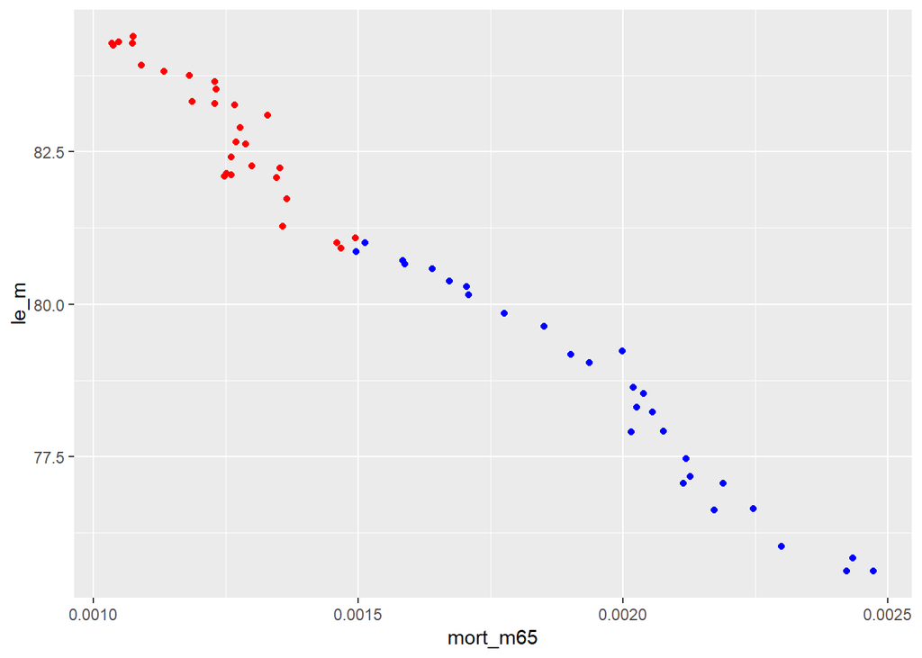

```r
ggplot(df_comp) +
  geom_point(mapping = aes(x = mort_m65, y = le_m), col = 4)+
  geom_point(mapping = aes(x = mort_f65, y = le_f), col = 2)
```

# Vilken geografisk nivå är lämplig som aggregeringsnivå?

Med data för 1990 beräknades i etty första steg medellivslängd och förtida död per kommun. Med hjälp av en Monte Carlo-simulering erhölls kommunspecifika fördelningar av medellivslängd tillsammans med ett 95% konfidensintervall samt standardfel. I ett andra steg undersökte jag hur standardfelet förändras med olika popualtionsstorlekar.

## Steg 1: Medellivslängd och förtida död på kommunnivå

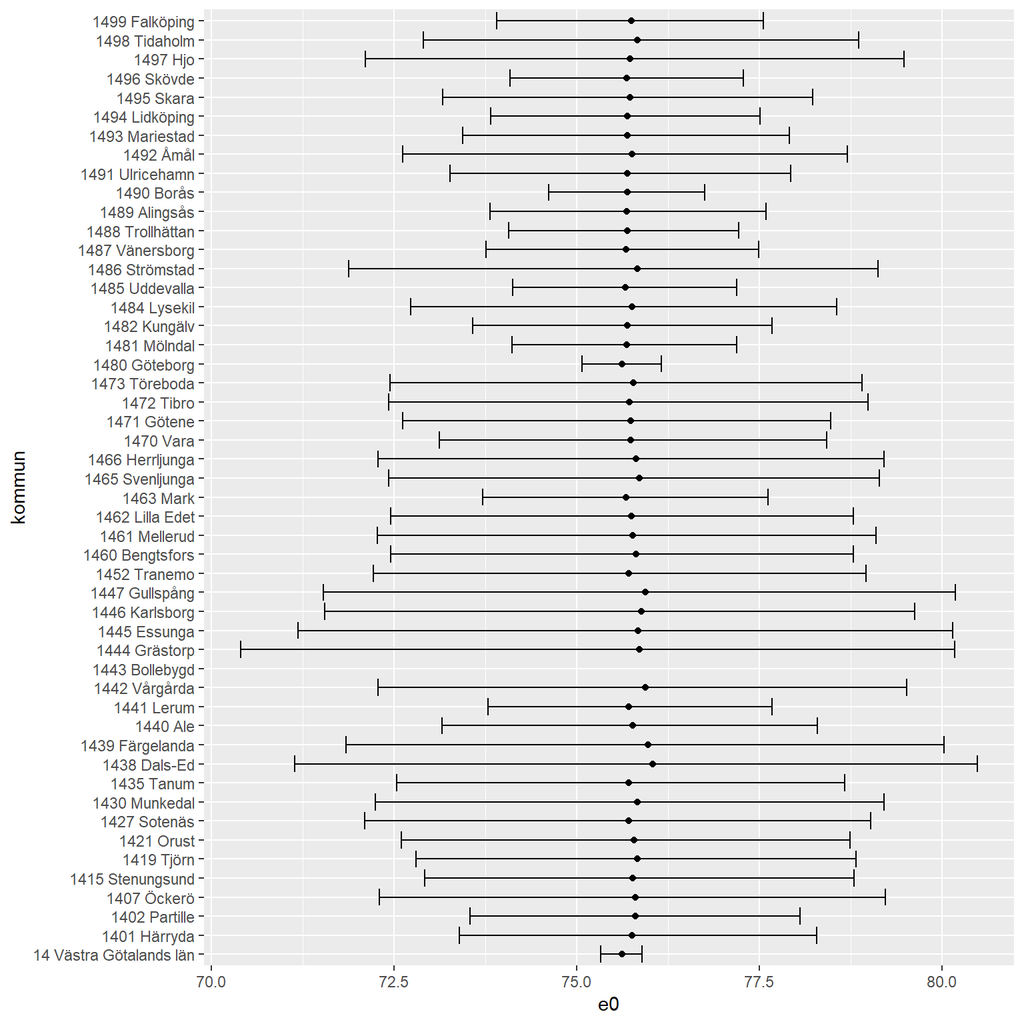

```r
df_e0 <- read_csv("resultat/compare_munics_male.csv")
ggplot(df_e0, aes(x = kommun, y = e0))+
  geom_point()+
  geom_errorbar(aes(ymin = ci_low, ymax = ci_high))+
  coord_flip()
```

Punktskattningarna varierar mellan 75.6 och 76 år. Men som blir uppenbart är osäkerheten i skattningarna mycket stor och det är enbart på regionnivå som precisionen understiger ett halvt levnadsår.

På liknande sätt förhåller det sig med precisionen i skattningar av vförtida dödsfall.

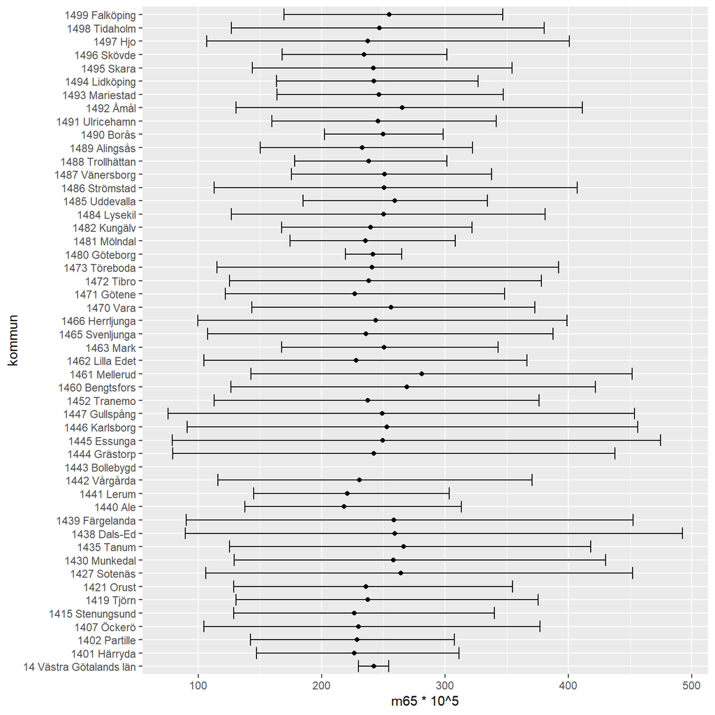

```r
ggplot(df_e0, aes(x = kommun, y = m65*10^5))+
 geom_point()+
 geom_errorbar(aes(ymin = ci_low65*10^5, ymax = ci_high65*10^5))+
 coord_flip()
```

Även här är punktskattningarna relaivt samlade mellan 218 och 281. Det är enbart på regionnivå och i Göteborg som konmfidensintervallet är omkring $\pm$ 20 döda per 100 000.

## Steg2: “Titrering” av standardavvikelsen

I nedasntående figur redovisas hur standardavvikelsen för medellivslängd berpor av populationsstorleken. Därigenom kan man få en uppfattning om hur stor populationen bör vara för att uppnå en önskad precision.

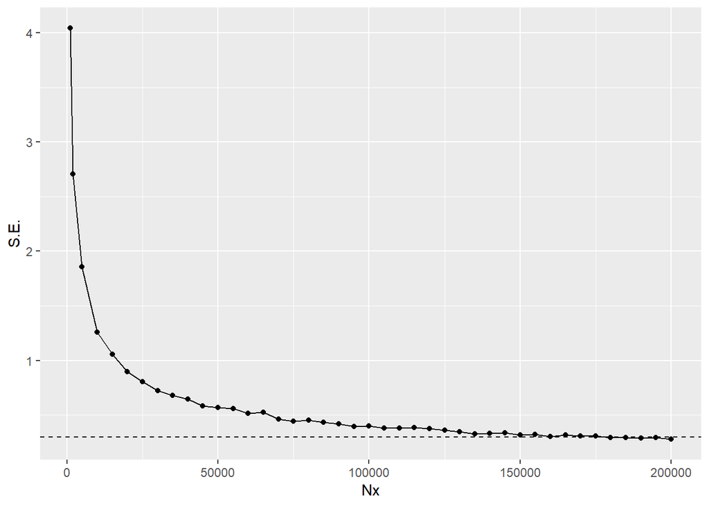

```r
df_e0 <- read_csv("resultat/compare_nx_e0_male.csv")

ggplot(df_e0, aes(x = Nx, y = S.E.))+
  geom_point()+
  geom_line()+
  geom_hline(yintercept = 0.3, linetype = 2)  # se = 0.3 motsvarar ett CI på +/- 0.6 år.
```

I figuren är populationsstorleken på x-axeln och standardfelet anges på y-axeln. Den streckade linjen anger ett standardfel på 0.3 vilket motsvarar en osäkerhet på ca $\pm$ 0.6 levnadsår. Det är först då man kommer upp i en population på omkring 150 000 - 175 000 individer som denna precision nås.

Motsvarande resultat för förtida dödsfall ses i figuren nedan.

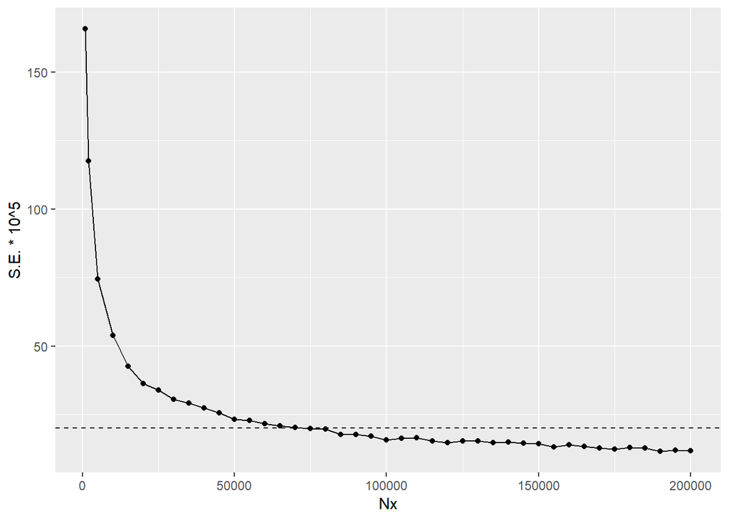

```r
tmp <- read_csv("resultat/compare_nx_m65_male.csv")

ggplot(tmp, aes(x = Nx, y = S.E.*10^5))+
  geom_point()+
  geom_line()+
  geom_hline(yintercept = 0.0002*10^5, linetype = 2)  # se = 0.3 motsvarar ett CI på +/- 0.6 år.
```

# Hur påverkas precisionen av att poola data?

Att poola data innebär i princip att man ökar antalet individer och därmed precisionen. Det kan göras på i princip två sätt: genom att aggregera observationer över tid och att aggregera individer geografiskt.

## Poola data över tid

Genom att poola data över tid, i detta fall 3- respektive 5 år, ökar man antalet observationer och därmed precisionen. Effekten illustreras i nedanstående graf som visar utfallet för Orust kommun, som ett exempel.

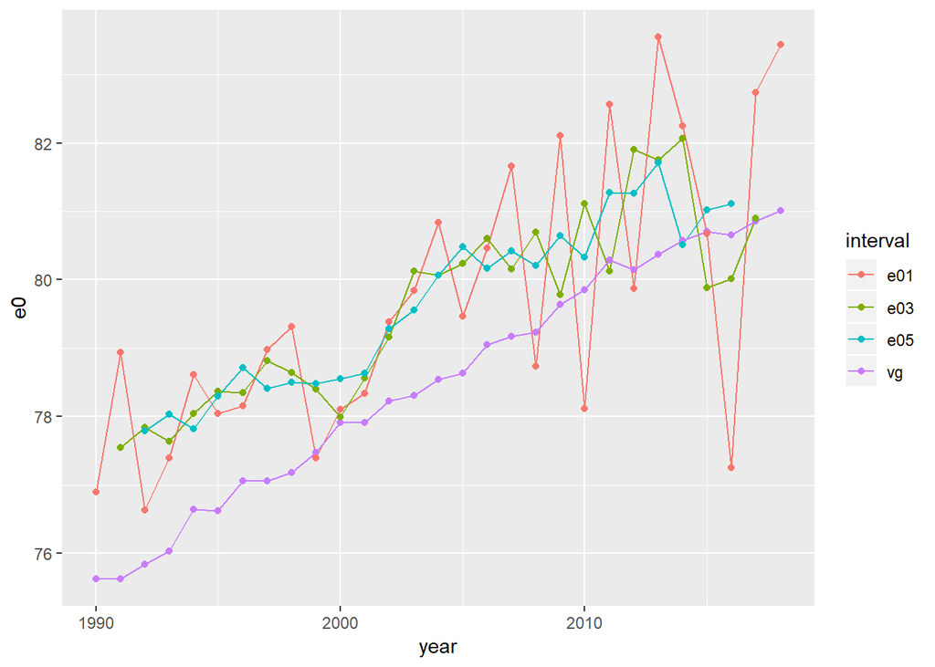

```r
### väljer 1421
nyears = 29

source("funcs/ind_funcs.R")

e01_1421 <- f_lifeexp(df_le_1421)

e03_1421 <- read_csv("resultat/df_e03.csv") %>%
  filter(substr(kommun, 1, 4) == "1421") %>%
  mutate(year = year - 1)

e05_1421 <- read_csv("resultat/df_e05.csv") %>%
  filter(substr(kommun, 1, 4) == "1421") %>%
  select(-kommun, year, e05 = e0) %>%
  mutate(year = year - 2)


e0_comp_vg <- tibble(year = 1990:2018, vg = df_comp$le_m)

e0_comp_1421 <- tibble(year = 1990:2018, e01 = as.numeric(e01_1421)) %>%
  full_join(e03_1421) %>%
  full_join(e05_1421) %>%
  full_join(e0_comp_vg) %>%
  select(year, vg, e01, e03 = e0, e05) %>%
  gather(key = interval, value = e0, -year)


ggplot(e0_comp_1421, aes(x = year, y = e0, color = interval)) +
  geom_line()+
  geom_point()
```

## Förtida död

Antalet förtida dödsfall har minskat i Västra Götalqand, från ca 250 per 100 000 män år 1990 till omkring 150 per 100 000. Hur ter sig motsvarande trend i en mindre kommun? I figuren nedan illustreras detta med data från Orust. 1-årsdata (röd linjke) visar en avseväred variation och det är svårt att utläsa om trenden har en riktning.

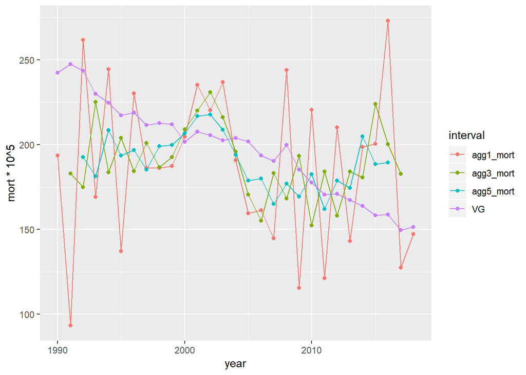

```r
#males
tmp_vg_m <- df_le_m %>%
  filter(substr(region, 1, 4) == "14 V" & ålder < 65) %>%
  group_by(year) %>%
  summarise(cases = sum(cases),
            antal = sum (antal)) %>%
  mutate(VG = cases/antal)

tmp1421m <- df_le_1421 %>%
  filter(substr(region, 1, 4) == "1421" & ålder < 65) %>%
  group_by(year) %>%
  summarise(cases = sum(cases),
            antal = sum (antal)) %>%
  mutate(agg1_mort = cases/antal,
         VG = tmp_vg_m$VG)



# ggplot(tmp1421m, aes(year, mort))+
#   geom_line()



agg3_cases = roll_sum(as.matrix(tmp1421m$cases), 3)
agg3_antal = roll_sum(as.matrix(tmp1421m$antal), 3)
agg5_cases = roll_sum(as.matrix(tmp1421m$cases), 5)
agg5_antal = roll_sum(as.matrix(tmp1421m$antal), 5)

agg3_mort = agg3_cases / agg3_antal
agg5_mort = agg5_cases / agg5_antal

tmp3 <- tibble(year = 1989:2017, agg3_mort) %>%
  filter(year > 1990)

tmp5 <- tibble(year = 1988:2016, agg5_mort) %>%
  filter(year > 1991)

fd1421m <- full_join(tmp1421m, tmp3)

fd1421m <- full_join(fd1421m, tmp5) %>%
  select(-c(cases, antal)) %>%
  gather(key = interval, value = mort, -year) %>%
  filter(year > 1989)

ggplot(fd1421m, aes(x = year, y = mort*10^5, color = interval))+
  geom_line()+
  geom_point()
```

Variationen minskar påtagligt med hjälp av rullande 3-års medelvärden (grön linje) och ger intyryck av att mortaliteten varit relativt oförändrad över tid med en period av minskande dödlighet i början av 2000-talet men en ökning under 2010-talet. Samma bild ges med hjälp av rullande 5-årsmedelvärden vilket också minskar vartiationen ytterligare.

Frågan är om detta ska ses som en “sann” fluktuation - skiljer sig dödligheten i Orust ommun från den i länet som helhet eller är fluktuationen en effekt av slumpmässig variation? För att närma oss ett svar gjordes en Monte Carlo-simulering med rullande 3-årsmedelvärden för att få fram en skattning av precisionen i dessa observationer.

Resulatet redovisas i figuren nedan. Den heldragna linjen motsvarar det skattade 3-årsmedelvärdet, det blå området beskriver ett 95%-konfidensintervall och den streckade linjen anger förtida dödlighet på länsnivå.

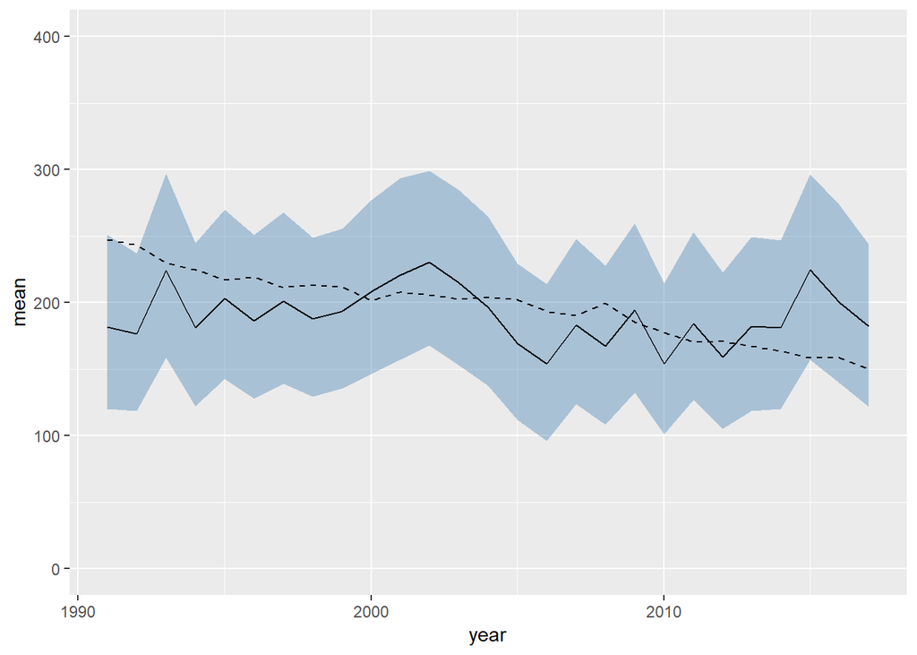

```r
tbl1421 <- read_csv("resultat/premdeaths1421.csv")

ggplot(tbl1421, aes(x = year, y = mean))+
  geom_ribbon(aes(ymin = low_ci, ymax = high_ci), fill = "steelblue", alpha = 0.4)+
  geom_line()+
  geom_line(aes(x= year, y = vg), linetype = 2)+
  ylim(0, 400)
```

Trots poolade data är osäkerheten i skatningarna batydande och omsluter i stort sett läns-trenden. Man kan inte med säkerhet hävda att dödligheten på Orust skiljer sig från den i länet.

## poolade data utiffrån geografiska områden

Vi har sett att osäkerheten i skattningar på kommunnivå är osäker. Men vad händer om vi aggregerar data till andra geografiska nivåer? Som vi sett är precisionen fr.a. avhängigt popualtionsstorleken. Därmed kan man anta att ju större geografiskt område desto större popualtion och därmed större precision. Lokala arbetsmarknader (LA 2014) är sju stycken i VG och omfattar alltså i genomsnitt 7 kommuner. En tänkbar högre aggergeringsnivå är de fyra kommunalförbunden alternativt de fem hälso- och sjukvårdsnämnderna.

I tabellen nedan framgår populationsstorleken i respektive geografiskt område.

```r
pop2018 <- df_mort %>%
  filter(year == 2018) %>%
  group_by(region, kön) %>%
  summarise(pop = sum(antal))

codes <- read_csv("data/KommunkoderMM.csv")

pop2018 <- left_join(pop2018, codes, by = c("region" = "numtext")) %>%
  select(kön, region, la14, kf, hsn, pop) %>%
  filter(region != "14 Västra Götalands län") %>%
  ungroup() %>%
  mutate(la_t = paste0("la14_", la14),
         kf_t = paste0("kf_", kf)) %>%
  fill()

pop_la14 <- pop2018 %>%
  group_by(kön, geo = la_t) %>%
  summarise(pop = sum(pop))%>%
  spread(key = kön, value = pop)

pop_kf <- pop2018 %>%
  group_by(kön, geo = kf_t) %>%
  summarise(pop = sum(pop))%>%
  spread(key = kön, value = pop)

pop_hsn <- pop2018 %>%
  group_by(kön, geo = hsn) %>%
  summarise(pop = sum(pop))%>%
  spread(key = kön, value = pop)

df1 <- cbind("id" = rownames(pop_la14), pop_la14)
df2 <- cbind("id" = rownames(pop_kf), pop_kf)
df3 <- cbind("id" = rownames(pop_hsn), pop_hsn)

tmp_tbl <- full_join(df1, df2, by = "id")
tmp_tbl <- full_join(tmp_tbl, df3, by = "id") %>%
  select(-id)

## tabell 1. Antal elever som deltagit i undersökningen

hx <- hux(tmp_tbl)

  heads1 <- c("Lokala arbetsmarknader", "", " ", "Kommunalförbund", " ", "", "HSN", "", "")
  heads2 <- c(" ", "Kvinnor", "Män", "", "Kvinnor", "Män", " ", "Kvinnor", "Män")

  hx%>% insert_row(heads2, after = 0) %>%
    insert_row(heads1, after = 0)%>%
    merge_cells(c(1, 1), c(1, 3)) %>%
    merge_cells(c(1,1), c(4, 6)) %>%
    merge_cells(c(1,1), c(7, 9)) %>%
    set_bottom_border(2, 1:9, 1) %>%
    set_bottom_border(10, 1:9, 1) %>%
    set_top_border(1, 1:9, 1) %>%
    set_align(1:2, 1:9, "center") %>%
#    set_align(1, 1:9, "center") %>%
    set_width(0.8) %>%
    set_number_format(row = 3:10, col = 1:9, value = 0)%>%
    theme_blue() %>%
    set_background_color(row = 1:2, col = 1:9, "steelblue") %>%
    set_background_color(row = 1:10, col = c(1, 4, 7), "steelblue") %>%
    set_bold(1:10, c(1, 4, 7), TRUE) %>%
    set_text_color(row = 1:2, col = 1:9, "white") %>%
    set_text_color(row = 1:10, col = c(1, 4, 7), "white") %>%
    set_caption("Antal kvinnor och män per geografiskt område")
```

Antal kvinnor och män per geografiskt område

| Lokala arbetsmarknader |  |  | Kommunalförbund |  |  | HSN |  |  |
| --- | --- | --- | --- | --- | --- | --- | --- | --- |
|  | Kvinnor | Män |  | Kvinnor | Män |  | Kvinnor | Män |
| la14_1 | 488938 | 492157 | kf_1 | 471154 | 473746 | hsn1 | 185309 | 187723 |
| la14_2 | 104088 | 106141 | kf_2 | 111304 | 113236 | hsn2 | 134858 | 138248 |
| la14_3 | 12821 | 13305 | kf_3 | 132164 | 135104 | hsn3 | 111304 | 113236 |
| la14_4 | 7038 | 7614 | kf_4 | 134858 | 138248 | hsn4 | 132164 | 135104 |
| la14_5 | 100948 | 102507 |  |  |  | hsn5 | 285845 | 286023 |
| la14_6 | 36916 | 37818 |  |  |  |  |  |  |
| la14_7 | 92415 | 94388 |  |  |  |  |  |  |
| la14_NA | 6316 | 6404 |  |  |  |  |  |  |

Den aggregeringsnivå som är närmast ovanför kommunen är de lokala arbetsmarknaderna. LA14 betcknar lokala arbetsmarknadaer enligt 12014 års indelning och är 7 stycken. Antalet invånare varierar mellan drygt 6000 till nästan ½ miljon. En beräkning av mortaliteten med befolkingen per lokal arbetsmarknad skulle leda till ett obalanserat dataset med mycket olika precision. Detsamma gäller kommunalförbundsnivån där antalet förvisso är jämt mellan jsuhärads KF, Fyrbodals KF och Skaraborgs KF men där befolkningen i Göteborgsregionen är omkring fuyra gånger så stor som i de övriga förbunden. En något jämnare situation finns beträffade befolkingarna i hälso- och sjukvårdsnämnderna även om befolkningen i HSN Götenborg är betydligt större.

# Diskussion

Medellivslängden har liksom i riket i övrigt ökat i Västra Götaland, både bland män och kvinnor (se Medellivslängdens utveckling 1990 - 2018), för män i Västra Götaland är medellivslängden f.n. 81 år och för kvinnor drygt 84 år. På motsvarande sätt har förtida dödlighet (definierat som antal dödsfall per 100 000 i befolkningen under 65 års ålder) sjunkit betydligt (Utvecklingen av förtida dödsfall 1990 - 2018).

Men om man är intresserad av att veta hur medellivslängden utvecklas på t.ex. kommunnivå stöter man på problemet med de små talens förbannelse - antalet inträffade dödsfall är helt enkelt för få för att göra säkra skattningar då befiolkningen är mindre eftersom slumpmässigt inträffade dödsfall påverkar medellivslängden i större utsträckning om befolkningsunderlaget är litet. Det innebär att enstaka dödsfall i yngr åldrar kan ha stor betdelse för medellivslängden. Bewräkningen av medellivslängden är mer komplicerad än beräknngen av förtida dödsfall - medan den senare innebär att man summerar antalet dödsfall under 65 års ålder och dividerar med befolkningen i samma åldersintervall, beräknas medellivslängden med hjälp av åldersspecifika dödstal, i detta fall dödlighet per 1-årsintervall, vilka därefter används i en s.k. livslängdstabell vilken utgår från en bestämd fiktiv folkmängd, vanligen 100 000 vid åldern 0 och som reduceras med hjälp av de ålderspecifika dödstalen för varje levnadsår till dess inga individer återstår av den fiktiva populationen. Medellivslängden brukar då definieras som den genomsnittliga förväntade livslängden vid födelsen under antagandet att de framtida dödsriskerna är desamma som används för beräkningen.

Av detta följer att (den slumpmässiga) variationen vid beräknng av medellivslängd uppstår på två sätt - dels finns en variation i vardera av de åldersspecifika dödsriskerna, dels finns en varuiation *mellan* de ålderspecifika dödsriskerna. Vid beräkningen av förtida dölighet uppstår variationen enbart i skattnngen av antalet dödsfall i relation till populationen och kan därmed sägas vara mindre känslig för slumpmässiga förändringar.

Följer man detta resonemang behövs alltså väsentligt större populationer för att kunna göra meningsfulla beräkningar av medellivslängd men även av förtida dödlighet. Det finns två sätt att “öka” befolkingsstorleken: genom att poola data över flera år och genom att slå samman geografiska områden, t.ex. kommuner till större geografiska områden. Man inser genast att för de mindre kommunerna behöver man poola data för många år för att nå en rimlig säkerhet. I exemplen ovan beräknades medellivslängd respektive förtida dödlighet för Orust kommun. Även med data poolade över 5 år blir osäkerheten relativt stor, för medellivslängd omkring 1 levnadsår, för förtida dödlighet omkring 25 förtida dödsfall per 100 000. Beträffande förtida dödlighet ger utvecklingen över tid ett intryck av en relativt stabil trend i Orust kommun där dödligheten legat kring 200 per 100 000 invånare. men som framgår av figuren är osäkerheten ändå så pass stor att man inte helt kan utesluta att den “sanna” trenden i orust är densamma som för regionen i sin helhet.

Man kan naturligtvis poola data över längre tid men måste väga det mot att man tappar information om en underliggande trend. Om man poolar data över t.ex. en 10-årsperiod kommer man att missa att dödligheten i början av perioden sannolikt var högre än i slutet av perioden.

# Slutsatser

underliggande risk vs. observerade värden

# Tabeller

[^1]: SCB: Livslängden i Sverige 2011–2015. Livslängdstabeller för riket och länen.Demografiska rapporter: Rapport 2016:4.